# Test

Jeppe Bundsgaard

2/3/2020

#### Test of local independence

### Local dependence

MP5_udstillingsarkitektFoerst and TP1_lydmax

MP5_skuespillerSidst and MP5_omviserSidst

MP13_busUdFoerst and MP13_busHjemSidst

MP13_overlapServeringTale and MP13_ikkeOverlapServeringTur

MP13_ikkeOverlapServeringTur and MP13_busHjemSidst, MP13_serveringvarighed

TP1_forestillinglaengst and TP1_kostmax, TP1_lydmax, TP1_forestillingsidst

TP1_kostmax and TP1_lydmax

TP1_manusfoerst and TP1_oeveefteraudition

TP1_oeveefteraudition and TP1_kostumeefteraudition, TP1_lydefterkoebelyd

TP1_kostumeefteraudition and TP1_lydefterkoebelyd

TP4_slutfoerst and TP4_sminkoerfoerst

TP4_sminkoerfoerst and TP4_auditionfoerst

|  | M5a | M5b | M5c | M5d | M5e | M13a | M13b | M13c | M13d | M13e | M13f | M13g | M13h | T1a | T1b | T1c | T1d | T1e | T1f | T1g | T1h | T1i | T4a | T4b | T4c |
| --- | --- | --- | --- | --- | --- | --- | --- | --- | --- | --- | --- | --- | --- | --- | --- | --- | --- | --- | --- | --- | --- | --- | --- | --- | --- |
| M5a: MP5_overlapSkuespillerOmviser |  | -0.35 | 0.07 | 0.18 | -0.02 | -0.32 | 0.27 | -0.28 | -0.27 | 0.37 | -0.01 | 0.04 | -0.03 | -0.11 | 0.1 | 0.06 | 0.17 | -0.13 | -0.2 | -0.3 | -0.16 | -0.12 | -0.14 | 0.05 | 0.06 |
| M5b: MP5_udstillingsarkitektFoerst |  |  | 0.28 | -0.1 | -0.34 | -0.03 | -0.19 | 0.13 | -0.22 | -0.15 | -0.15 | -0.18 | -0.16 | -0.03 | -0.3 | -0.24 | -0.54 ** | 0.09 | 0.07 | -0.04 | 0.03 | 0.27 | -0.14 | -0.02 | 0.12 |
| M5c: MP5_skuespillerSidst |  |  |  | 0.87 *** | 0.37 | -0.05 | 0.13 | 0.04 | -0.09 | -0.21 | -0.18 | 0.15 | 0.16 | 0.2 | -0.24 | -0.25 | -0.12 | -0.08 | 0.3 | -0.44 | -0.19 | 0.02 | -0.24 | 0.06 | -0.11 |
| M5d: MP5_omviserSidst |  |  |  |  | 0.37 | -0.17 | 0.15 | -0.2 | -0.22 | -0.09 | -0.15 | 0.07 | 0.26 | 0.37 | -0.03 | -0.02 | 0.06 | -0.19 | 0.23 | -0.3 | -0.02 | -0.06 | -0.13 | 0.03 | -0.31 |
| M5e: MP5_udstillingLaengst |  |  |  |  |  | 0.08 | 0.24 | -0.03 | -0.03 | 0.17 | 0.05 | 0.34 | 0.09 | 0.11 | 0.07 | 0.1 | -0.06 | -0.05 | -0.17 | -0.21 | -0.22 | -0.11 | -0.01 | 0.03 | 0.02 |
| M13a: MP13_busUdFoerst |  |  |  |  |  |  | 0.09 | 0.52 | 0.77 *** | -0.12 | 0.13 | 0.35 | 0.23 | 0.18 | -0.27 | -0.12 | 0.04 | -0.03 | 0.09 | 0.04 | -0.14 | 0.17 | -0.13 | -0.23 | -0.27 |
| M13b: MP13_overlapServeringTale |  |  |  |  |  |  |  | -0.58 ** | -0.28 | 0.04 | 0.01 | 0.12 | -0.21 | -0.46 | -0.24 | -0.16 | 0 | -0.03 | -0.14 | -0.22 | -0.15 | -0.06 | -0.14 | 0.05 | 0 |
| M13c: MP13_ikkeOverlapServeringTur |  |  |  |  |  |  |  |  | 0.6 ** | -0.26 | 0.6 ** | 0.46 | 0.19 | 0.41 | -0.14 | 0.16 | -0.1 | -0.13 | 0.21 | -0.19 | -0.25 | -0.15 | 0.04 | -0.06 | -0.11 |
| M13d: MP13_busHjemSidst |  |  |  |  |  |  |  |  |  | -0.16 | 0.29 | 0.5 . | 0.2 | 0.04 | -0.06 | 0.09 | 0.03 | -0.13 | 0.05 | 0.03 | -0.1 | -0.02 | 0.01 | -0.22 | -0.16 |
| M13e: MP13_turvarighed |  |  |  |  |  |  |  |  |  |  | 0.28 | 0.12 | -0.32 | -0.49 | 0.25 | 0.18 | 0.07 | -0.22 | 0 | -0.34 | -0.18 | -0.12 | 0.04 | 0.14 | 0.03 |
| M13f: MP13_serveringvarighed |  |  |  |  |  |  |  |  |  |  |  | -0.18 | -0.07 | -0.05 | 0.36 | 0.33 | -0.1 | 0.03 | -0.44 | -0.12 | -0.14 | -0.36 | 0 | 0.15 | 0.16 |
| M13g: MP13_talevarighed |  |  |  |  |  |  |  |  |  |  |  |  | 0.26 | 0.19 | -0.13 | 0.27 | -0.09 | -0.03 | 0.32 | -0.26 | -0.46 | -0.17 | -0.2 | -0.19 | -0.02 |
| M13h: MP13_busUdHjemEns |  |  |  |  |  |  |  |  |  |  |  |  |  | 0.51 | 0.31 | 0.11 | 0.01 | 0.36 | -0.04 | 0.11 | -0.05 | -0.15 | 0.05 | -0.19 | -0.17 |
| T1a: TP1_forestillinglaengst |  |  |  |  |  |  |  |  |  |  |  |  |  |  | -0.24 | -1 *** | -1 *** | -0.72 | -1 *** | -0.73 | -0.56 | -0.49 | -0.02 | 0.04 | -0.03 |
| T1b: TP1_auditmax |  |  |  |  |  |  |  |  |  |  |  |  |  |  |  | 0.34 | 0.27 | 0.24 | 0.02 | 0.1 | 0.31 | 0.08 | 0.06 | -0.16 | -0.1 |
| T1c: TP1_kostmax |  |  |  |  |  |  |  |  |  |  |  |  |  |  |  |  | 0.71 *** | -0.09 | -0.07 | -0.06 | 0 | -0.25 | -0.17 | 0.04 | -0.03 |
| T1d: TP1_lydmax |  |  |  |  |  |  |  |  |  |  |  |  |  |  |  |  |  | 0.03 | -0.02 | -0.04 | 0.2 | 0.04 | 0.15 | -0.08 | -0.18 |
| T1e: TP1_manusfoerst |  |  |  |  |  |  |  |  |  |  |  |  |  |  |  |  |  |  | 0.32 | 0.56 ** | 0.26 | 0.1 | -0.14 | -0.26 | -0.13 |
| T1f: TP1_forestillingsidst |  |  |  |  |  |  |  |  |  |  |  |  |  |  |  |  |  |  |  | 0.26 | 0.16 | 0.2 | -0.04 | -0.14 | -0.2 |
| T1g: TP1_oeveefteraudition |  |  |  |  |  |  |  |  |  |  |  |  |  |  |  |  |  |  |  |  | 0.82 *** | 0.55 ** | 0.21 | -0.42 | -0.18 |
| T1h: TP1_kostumeefteraudition |  |  |  |  |  |  |  |  |  |  |  |  |  |  |  |  |  |  |  |  |  | 0.53 ** | -0.05 | -0.08 | -0.08 |
| T1i: TP1_lydefterkoebelyd |  |  |  |  |  |  |  |  |  |  |  |  |  |  |  |  |  |  |  |  |  |  | -0.03 | -0.12 | -0.01 |
| T4a: TP4_slutfoerst |  |  |  |  |  |  |  |  |  |  |  |  |  |  |  |  |  |  |  |  |  |  |  | 0.41 *** | 0.32 |
| T4b: TP4_sminkoerfoerst |  |  |  |  |  |  |  |  |  |  |  |  |  |  |  |  |  |  |  |  |  |  |  |  | 0.65 *** |
| T4c: TP4_auditionfoerst |  |  |  |  |  |  |  |  |  |  |  |  |  |  |  |  |  |  |  |  |  |  |  |  |  |

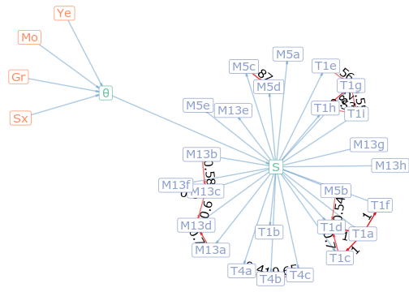

#### Test of local independence

### Local dependence

CP10_delopgB2 and CP10_delopgB5

CP10_delopgB3 and CP10_delopgB4, CP10_delopgB5, CP16_buffetVarighed

CP10_delopgB5 and CP10_delopgB6

CP10_delopgB8 and TP1_forestillinglaengst

CP16_baalSidst and CP16_boernAktFoerst, CP16_taleAlene, CP16_faellessangAlene, TP1_forestillinglaengst

CP16_taleAlene and CP16_faellessangAlene, CP16_taleVarighed, CP16_faellessangVarighed, CP16_buffetVarighed

CP16_faellessangAlene and CP16_faellessangVarighed, CP16_buffetVarighed

CP16_taleVarighed and CP16_faellessangVarighed

CP16_buffetVarighed and TP1_forestillinglaengst

TP1_forestillinglaengst and TP1_lydmax, TP1_manusfoerst, TP1_forestillingsidst, TP1_oeveefteraudition, TP1_lydefterkoebelyd

TP1_kostmax and TP1_lydmax

TP1_manusfoerst and TP1_forestillingsidst

TP1_forestillingsidst and TP1_oeveefteraudition

TP1_oeveefteraudition and TP1_kostumeefteraudition

TP4_slutfoerst and TP4_auditionfoerst

TP4_sminkoerfoerst and TP4_auditionfoerst

|  | C10a | C10b | C10c | C10d | C10e | C10f | C10g | C10h | C16a | C16b | C16c | C16d | C16e | C16f | C16g | T1a | T1b | T1c | T1d | T1e | T1f | T1g | T1h | T1i | T4a | T4b | T4c |
| --- | --- | --- | --- | --- | --- | --- | --- | --- | --- | --- | --- | --- | --- | --- | --- | --- | --- | --- | --- | --- | --- | --- | --- | --- | --- | --- | --- |
| C10a: CP10_delopgB1 |  | -0.05 | 0.38 | 0.03 | 0.15 | 0.1 | 0.28 | 0.08 | -0.05 | 0.01 | -0.01 | 0.06 | -0.14 | 0.05 | -0.21 | 0.51 | -0.12 | 0.11 | -0.05 | 0.05 | -0.18 | -0.18 | 0 | -0.27 | -0.08 | 0 | -0.07 |
| C10b: CP10_delopgB2 |  |  | 0.59 | 0.42 . | 0.48 *** | 0.21 | 0.08 | 0.26 | -0.12 | -0.06 | 0.07 | -0.01 | 0.26 | -0.14 | -0.26 | -0.51 | -0.21 | -0.15 | -0.21 | -0.1 | -0.13 | 0.04 | -0.27 | 0.04 | -0.09 | -0.09 | -0.09 |
| C10c: CP10_delopgB3 |  |  |  | 0.89 *** | 0.77 *** | 0.45 | 0.31 | 0.59 | 0.1 | 0.11 | -0.24 | -0.55 | -0.29 | 0.04 | -0.87 *** | 0.11 | -0.1 | 0.14 | -0.38 | 0.11 | 0.06 | -0.34 | 0.21 | 0.09 | -0.31 | 0.01 | -0.15 |
| C10d: CP10_delopgB4 |  |  |  |  | 0.03 | -0.14 | 0.2 | 0.31 | -0.05 | -0.04 | -0.03 | 0.06 | -0.26 | -0.08 | -0.04 | 0 | 0.11 | 0.2 | -0.01 | -0.14 | 0.04 | -0.17 | -0.4 | -0.21 | -0.06 | -0.2 | -0.13 |
| C10e: CP10_delopgB5 |  |  |  |  |  | 0.79 *** | 0.01 | 0.45 | 0.16 | 0.09 | 0.05 | -0.09 | 0.08 | -0.22 | -0.24 | -0.08 | -0.02 | -0.02 | -0.16 | 0.03 | 0.07 | -0.27 | -0.27 | 0.08 | -0.22 | 0 | -0.16 |
| C10f: CP10_delopgB6 |  |  |  |  |  |  | -0.1 | 0.09 | -0.09 | -0.09 | -0.09 | -0.08 | -0.17 | -0.3 | -0.12 | -0.44 | 0.02 | -0.05 | -0.16 | 0.04 | 0.06 | -0.22 | 0.04 | 0.02 | -0.22 | 0.1 | -0.11 |
| C10g: CP10_delopgB7 |  |  |  |  |  |  |  | 0.1 | 0.01 | 0.05 | -0.16 | -0.25 | 0.07 | 0.05 | -0.13 | 0.32 | 0.04 | 0 | 0.06 | 0.09 | -0.08 | -0.02 | -0.14 | -0.26 | -0.22 | -0.05 | -0.13 |
| C10h: CP10_delopgB8 |  |  |  |  |  |  |  |  | 0.35 | 0.11 | -0.1 | -0.4 | -0.28 | -0.1 | -0.39 | 1 *** | 0.21 | 0.35 | -0.08 | -0.02 | -0.18 | -0.51 | -0.3 | -0.05 | 0.32 | -0.13 | 0.23 |
| C16a: CP16_baalSidst |  |  |  |  |  |  |  |  |  | 0.82 *** | 0.65 *** | 1 *** | 0.53 | 0.35 | 0.5 | 1 *** | -0.35 | -0.38 | -0.14 | -0.27 | -0.06 | -0.2 | -0.35 | -0.36 | -0.11 | -0.09 | -0.32 |
| C16b: CP16_boernAktFoerst |  |  |  |  |  |  |  |  |  |  | 0.18 | 0.03 | 0.12 | -0.07 | 0.11 | 0.46 | -0.16 | 0 | 0.03 | -0.3 | -0.12 | -0.15 | -0.24 | 0.08 | -0.13 | 0.01 | -0.03 |
| C16c: CP16_taleAlene |  |  |  |  |  |  |  |  |  |  |  | 0.84 *** | 0.6 *** | 0.44 * | 0.57 ** | 0.72 | -0.07 | -0.2 | 0.09 | -0.14 | -0.19 | -0.23 | -0.18 | -0.04 | -0.19 | 0.04 | -0.22 |
| C16d: CP16_faellessangAlene |  |  |  |  |  |  |  |  |  |  |  |  | 0.39 | 0.71 *** | 1 *** | 0.71 | -0.18 | -0.18 | 0.15 | 0.01 | 0.03 | -0.46 | -0.51 | -0.03 | -0.15 | 0.14 | -0.25 |
| C16e: CP16_taleVarighed |  |  |  |  |  |  |  |  |  |  |  |  |  | 0.57 ** | 0.26 | 0.21 | -0.17 | -0.27 | -0.08 | -0.29 | 0.08 | 0.1 | -0.24 | -0.14 | -0.14 | -0.02 | -0.23 |
| C16f: CP16_faellessangVarighed |  |  |  |  |  |  |  |  |  |  |  |  |  |  | 0.36 | 0.73 | -0.09 | 0 | 0.17 | -0.11 | 0.05 | -0.24 | -0.21 | 0.02 | -0.02 | -0.1 | -0.08 |
| C16g: CP16_buffetVarighed |  |  |  |  |  |  |  |  |  |  |  |  |  |  |  | 1 *** | 0 | -0.01 | 0.45 | -0.22 | 0.07 | -0.03 | -0.13 | -0.06 | 0.11 | 0.17 | -0.06 |
| T1a: TP1_forestillinglaengst |  |  |  |  |  |  |  |  |  |  |  |  |  |  |  |  | -0.21 | 0.55 | -1 *** | -1 *** | -1 *** | -1 *** | -0.75 | -0.89 *** | 0.11 | -0.28 | 0.19 |
| T1b: TP1_auditmax |  |  |  |  |  |  |  |  |  |  |  |  |  |  |  |  |  | 0.18 | 0.12 | 0.18 | 0.05 | 0.29 | 0.12 | 0.05 | 0.14 | -0.22 | -0.09 |
| T1c: TP1_kostmax |  |  |  |  |  |  |  |  |  |  |  |  |  |  |  |  |  |  | 0.57 ** | 0.13 | -0.09 | 0.11 | 0.2 | -0.1 | -0.09 | -0.09 | 0.07 |
| T1d: TP1_lydmax |  |  |  |  |  |  |  |  |  |  |  |  |  |  |  |  |  |  |  | 0.11 | 0.14 | 0.43 | -0.13 | 0.49 | -0.34 | -0.07 | 0 |
| T1e: TP1_manusfoerst |  |  |  |  |  |  |  |  |  |  |  |  |  |  |  |  |  |  |  |  | 0.57 *** | 0.32 | 0.47 | 0.19 | -0.03 | -0.09 | -0.34 |
| T1f: TP1_forestillingsidst |  |  |  |  |  |  |  |  |  |  |  |  |  |  |  |  |  |  |  |  |  | 0.56 ** | 0.44 | 0.35 | -0.03 | -0.09 | -0.29 |
| T1g: TP1_oeveefteraudition |  |  |  |  |  |  |  |  |  |  |  |  |  |  |  |  |  |  |  |  |  |  | 0.72 *** | 0.37 | -0.03 | -0.2 | -0.18 |
| T1h: TP1_kostumeefteraudition |  |  |  |  |  |  |  |  |  |  |  |  |  |  |  |  |  |  |  |  |  |  |  | 0.47 | 0 | -0.19 | 0.16 |
| T1i: TP1_lydefterkoebelyd |  |  |  |  |  |  |  |  |  |  |  |  |  |  |  |  |  |  |  |  |  |  |  |  | -0.26 | 0.06 | -0.06 |
| T4a: TP4_slutfoerst |  |  |  |  |  |  |  |  |  |  |  |  |  |  |  |  |  |  |  |  |  |  |  |  |  | 0.28 | 0.5 *** |
| T4b: TP4_sminkoerfoerst |  |  |  |  |  |  |  |  |  |  |  |  |  |  |  |  |  |  |  |  |  |  |  |  |  |  | 0.42 *** |
| T4c: TP4_auditionfoerst |  |  |  |  |  |  |  |  |  |  |  |  |  |  |  |  |  |  |  |  |  |  |  |  |  |  |  |

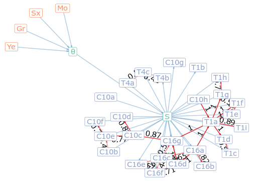

#### Test of local independence

### Local dependence

FP7_buffetvar and FP7_forlystelservar, FP7_optogvar

FP7_forlystelservar and FP7_fyrvaerkerisidst

FP7_optogvar and FP7_indgangfoerst

FP12_dans and FP12_modeltegning, FP12_kostumer, TP1_oeveefteraudition

FP12_modeltegning and FP12_kostumer

FP12_kostumer and TP1_oeveefteraudition

TP1_forestillinglaengst and TP1_kostmax, TP1_lydmax, TP1_forestillingsidst, TP1_oeveefteraudition

TP1_kostmax and TP1_lydmax

TP1_forestillingsidst and TP1_oeveefteraudition

TP1_oeveefteraudition and TP1_kostumeefteraudition, TP1_lydefterkoebelyd

TP1_kostumeefteraudition and TP1_lydefterkoebelyd

TP4_slutfoerst and TP4_auditionfoerst

TP4_sminkoerfoerst and TP4_auditionfoerst

|  | F7a | F7b | F7c | F7d | F7e | F7f | F7g | F7h | F12a | F12b | F12c | T1a | T1b | T1c | T1d | T1e | T1f | T1g | T1h | T1i | T4a | T4b | T4c |
| --- | --- | --- | --- | --- | --- | --- | --- | --- | --- | --- | --- | --- | --- | --- | --- | --- | --- | --- | --- | --- | --- | --- | --- |
| F7a: FP7_buffetvar |  | 0.45 * | 0.3 | 0.22 | 0.58 *** | 0.29 | 0.62 | 0.17 | -0.16 | -0.18 | -0.17 | 0.35 | -0.03 | 0.08 | 0.23 | 0 | -0.15 | 0.08 | -0.02 | -0.29 | -0.04 | -0.15 | -0.12 |
| F7b: FP7_forlystelservar |  |  | 0.38 | -0.29 | 0.3 | 0.13 | 0.46 | -0.42 * | -0.1 | 0.11 | -0.14 | 0.65 | 0.04 | 0.03 | 0.28 | 0.04 | -0.17 | 0.18 | 0.13 | -0.2 | 0.12 | -0.09 | -0.15 |
| F7c: FP7_fyrvaerkerivar |  |  |  | 0.46 | 0.39 | 0.01 | 0.64 | 0.14 | -0.2 | -0.27 | -0.24 | -0.31 | 0.12 | 0.2 | 0.28 | 0.02 | -0.01 | -0.01 | 0.04 | -0.25 | -0.04 | 0.22 | -0.14 |
| F7d: FP7_indgangvar |  |  |  |  | 0.22 | -0.15 | 0.49 | -0.03 | -0.04 | -0.02 | -0.1 | 0.55 | 0.22 | 0.1 | 0.14 | -0.23 | 0.01 | -0.09 | 0.11 | -0.15 | -0.11 | 0.19 | -0.05 |
| F7e: FP7_optogvar |  |  |  |  |  | -0.17 | 0.76 ** | 0.2 | -0.09 | -0.27 | -0.07 | -0.1 | 0.17 | 0.06 | 0.07 | 0.01 | 0.05 | -0.07 | 0.16 | -0.32 | -0.02 | -0.12 | -0.06 |
| F7f: FP7_klovnefoerst |  |  |  |  |  |  | 0.31 | 0.11 | 0.01 | 0.16 | -0.05 | 0.18 | -0.15 | -0.07 | 0.02 | -0.16 | 0.03 | -0.07 | -0.07 | -0.26 | -0.02 | -0.13 | -0.18 |
| F7g: FP7_indgangfoerst |  |  |  |  |  |  |  | 0.46 | -0.03 | -0.27 | -0.14 | 0.24 | -0.06 | -0.3 | 0.29 | 0.25 | 0.07 | -0.09 | -0.1 | -0.49 | 0.36 | 0.31 | 0.02 |
| F7h: FP7_fyrvaerkerisidst |  |  |  |  |  |  |  |  | 0.01 | -0.1 | 0.12 | 0.31 | 0.17 | -0.3 | 0.02 | -0.06 | 0.21 | 0.06 | -0.07 | 0.14 | -0.05 | -0.16 | -0.11 |
| F12a: FP12_dans |  |  |  |  |  |  |  |  |  | 0.35 ** | 0.67 *** | 0.3 | -0.16 | -0.13 | -0.02 | -0.19 | -0.31 | -0.54 *** | -0.31 | -0.05 | -0.03 | -0.05 | -0.05 |
| F12b: FP12_modeltegning |  |  |  |  |  |  |  |  |  |  | 0.49 *** | 0.62 | -0.25 | -0.04 | -0.06 | -0.19 | -0.28 | -0.27 | -0.2 | -0.3 | -0.05 | -0.13 | 0.13 |
| F12c: FP12_kostumer |  |  |  |  |  |  |  |  |  |  |  | 0.38 | -0.12 | -0.21 | -0.15 | -0.09 | -0.08 | -0.54 *** | -0.37 | -0.05 | -0.08 | -0.08 | -0.08 |
| T1a: TP1_forestillinglaengst |  |  |  |  |  |  |  |  |  |  |  |  | -0.62 | -1 *** | -1 *** | -0.78 | -0.88 *** | -0.98 *** | -0.51 | -0.64 | -0.23 | -0.16 | -0.3 |
| T1b: TP1_auditmax |  |  |  |  |  |  |  |  |  |  |  |  |  | 0.4 | 0.18 | 0.15 | 0.16 | 0.12 | 0.15 | 0.08 | 0.13 | -0.24 | -0.06 |
| T1c: TP1_kostmax |  |  |  |  |  |  |  |  |  |  |  |  |  |  | 0.62 *** | 0.25 | 0.33 | -0.01 | 0.26 | 0.03 | -0.19 | -0.12 | -0.11 |
| T1d: TP1_lydmax |  |  |  |  |  |  |  |  |  |  |  |  |  |  |  | -0.02 | 0.15 | 0.25 | 0.35 | 0.1 | -0.4 | -0.18 | -0.17 |
| T1e: TP1_manusfoerst |  |  |  |  |  |  |  |  |  |  |  |  |  |  |  |  | 0.38 | 0.22 | 0.09 | 0.04 | 0.16 | -0.08 | -0.17 |
| T1f: TP1_forestillingsidst |  |  |  |  |  |  |  |  |  |  |  |  |  |  |  |  |  | 0.54 *** | 0.3 | 0.43 . | -0.17 | -0.1 | -0.07 |
| T1g: TP1_oeveefteraudition |  |  |  |  |  |  |  |  |  |  |  |  |  |  |  |  |  |  | 0.74 *** | 0.52 ** | -0.2 | -0.03 | 0.21 |
| T1h: TP1_kostumeefteraudition |  |  |  |  |  |  |  |  |  |  |  |  |  |  |  |  |  |  |  | 0.53 *** | -0.31 | 0.05 | -0.05 |
| T1i: TP1_lydefterkoebelyd |  |  |  |  |  |  |  |  |  |  |  |  |  |  |  |  |  |  |  |  | 0.06 | 0.03 | 0.08 |
| T4a: TP4_slutfoerst |  |  |  |  |  |  |  |  |  |  |  |  |  |  |  |  |  |  |  |  |  | 0.32 . | 0.44 *** |
| T4b: TP4_sminkoerfoerst |  |  |  |  |  |  |  |  |  |  |  |  |  |  |  |  |  |  |  |  |  |  | 0.43 *** |
| T4c: TP4_auditionfoerst |  |  |  |  |  |  |  |  |  |  |  |  |  |  |  |  |  |  |  |  |  |  |  |

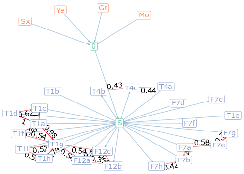

#### Test of local independence

### Local dependence

CP10_delopgB2 and CP10_delopgB3

CP10_delopgB3 and CP10_delopgB5

CP10_delopgB5 and CP10_delopgB6, CP10_delopgB7, CP10_delopgB8

CP10_delopgB6 and CP10_delopgB7, CP10_delopgB8

CP16_baalSidst and CP16_boernAktFoerst

CP16_taleAlene and CP16_faellessangAlene, CP16_taleVarighed, CP16_faellessangVarighed, CP16_buffetVarighed

CP16_faellessangAlene and CP16_taleVarighed, CP16_faellessangVarighed, CP16_buffetVarighed

CP16_taleVarighed and CP16_faellessangVarighed

MP5_overlapSkuespillerOmviser and MP5_udstillingsarkitektFoerst

MP5_skuespillerSidst and MP5_omviserSidst, MP5_udstillingLaengst

MP13_busUdFoerst and MP13_busHjemSidst

MP13_ikkeOverlapServeringTur and MP13_busHjemSidst, MP13_serveringvarighed

MP13_busHjemSidst and MP13_serveringvarighed

|  | C10a | C10b | C10c | C10d | C10e | C10f | C10g | C10h | C16a | C16b | C16c | C16d | C16e | C16f | C16g | M5a | M5b | M5c | M5d | M5e | M13a | M13b | M13c | M13d | M13e | M13f | M13g | M13h |
| --- | --- | --- | --- | --- | --- | --- | --- | --- | --- | --- | --- | --- | --- | --- | --- | --- | --- | --- | --- | --- | --- | --- | --- | --- | --- | --- | --- | --- |
| C10a: CP10_delopgB1 |  | -0.12 | 0.16 | 0.16 | 0.07 | 0.08 | 0.16 | 0.17 | -0.22 | -0.06 | -0.08 | 0.07 | -0.15 | -0.19 | -0.16 | 0.11 | -0.11 | -0.13 | -0.03 | 0.04 | -0.08 | 0.15 | -0.22 | -0.1 | 0.05 | -0.03 | -0.05 | -0.07 |
| C10b: CP10_delopgB2 |  |  | 0.58 *** | 0.18 | 0.26 | 0.07 | -0.09 | 0.24 | 0.3 | 0.02 | -0.1 | -0.17 | 0.14 | -0.04 | -0.16 | 0.2 | -0.12 | 0.02 | 0.01 | 0.11 | 0 | 0.09 | 0.08 | 0.06 | -0.13 | -0.03 | -0.06 | -0.03 |
| C10c: CP10_delopgB3 |  |  |  | 0.47 | 0.5 ** | 0.35 | 0.29 | 0.52 . | -0.38 | -0.2 | -0.14 | -0.36 | 0.16 | -0.49 | -0.28 | 0.21 | 0.12 | -0.16 | -0.38 | 0.15 | -0.04 | -0.1 | -0.5 | -0.12 | -0.36 | 0.09 | -0.14 | 0 |
| C10d: CP10_delopgB4 |  |  |  |  | -0.23 | -0.21 | 0.12 | -0.18 | -0.04 | -0.21 | -0.07 | -0.18 | -0.25 | -0.21 | -0.18 | -0.25 | 0.04 | -0.01 | 0.03 | -0.01 | -0.21 | -0.08 | -0.03 | -0.14 | -0.15 | -0.05 | -0.13 | -0.03 |
| C10e: CP10_delopgB5 |  |  |  |  |  | 0.74 *** | 0.34 ** | 0.55 *** | -0.06 | 0.05 | -0.1 | -0.06 | -0.1 | -0.08 | -0.36 | 0.2 | 0.06 | -0.03 | -0.1 | -0.21 | -0.17 | -0.06 | -0.05 | -0.22 | -0.06 | -0.02 | -0.03 | 0.23 |
| C10f: CP10_delopgB6 |  |  |  |  |  |  | 0.39 ** | 0.59 *** | 0.04 | -0.17 | -0.02 | -0.02 | 0.06 | -0.21 | 0.07 | 0.13 | 0.02 | -0.04 | -0.32 | -0.19 | -0.26 | 0.27 | -0.22 | -0.32 | 0.07 | -0.19 | -0.28 | 0.06 |
| C10g: CP10_delopgB7 |  |  |  |  |  |  |  | 0.25 | -0.37 | -0.09 | -0.18 | -0.27 | -0.09 | -0.1 | 0.03 | -0.06 | -0.05 | -0.18 | -0.24 | -0.04 | 0.04 | 0.3 | -0.01 | -0.17 | 0.13 | -0.18 | -0.24 | -0.25 |
| C10h: CP10_delopgB8 |  |  |  |  |  |  |  |  | 0 | -0.09 | -0.17 | -0.31 | 0.05 | -0.13 | -0.12 | 0.38 | -0.17 | 0.01 | -0.04 | 0.26 | -0.24 | 0.47 | -0.2 | -0.12 | 0.14 | -0.25 | -0.11 | 0.05 |
| C16a: CP16_baalSidst |  |  |  |  |  |  |  |  |  | 0.8 *** | 0.31 | 0.44 | 0.13 | -0.05 | 0.18 | 0.15 | 0.06 | 0.13 | 0.09 | -0.05 | -0.16 | -0.16 | -0.14 | -0.13 | -0.16 | -0.17 | 0.03 | -0.12 |
| C16b: CP16_boernAktFoerst |  |  |  |  |  |  |  |  |  |  | 0.21 | 0.31 | 0.01 | -0.01 | 0 | 0.17 | -0.07 | 0 | -0.14 | 0.01 | -0.17 | -0.06 | -0.05 | 0.07 | -0.01 | -0.03 | 0.14 | 0.09 |
| C16c: CP16_taleAlene |  |  |  |  |  |  |  |  |  |  |  | 0.88 *** | 0.71 *** | 0.46 *** | 0.63 *** | -0.16 | 0.18 | -0.21 | -0.12 | -0.02 | -0.04 | -0.25 | -0.02 | -0.09 | -0.22 | -0.01 | 0.24 | -0.03 |
| C16d: CP16_faellessangAlene |  |  |  |  |  |  |  |  |  |  |  |  | 0.65 *** | 0.72 *** | 0.78 *** | -0.14 | 0.15 | -0.27 | -0.21 | -0.13 | -0.03 | -0.33 | -0.18 | -0.28 | -0.4 | -0.1 | 0.19 | -0.06 |
| C16e: CP16_taleVarighed |  |  |  |  |  |  |  |  |  |  |  |  |  | 0.51 ** | 0.5 | -0.16 | -0.01 | -0.01 | -0.04 | -0.08 | -0.11 | -0.08 | 0.22 | -0.09 | -0.38 | 0 | 0.34 | 0.01 |
| C16f: CP16_faellessangVarighed |  |  |  |  |  |  |  |  |  |  |  |  |  |  | 0.38 | -0.18 | 0.19 | -0.03 | 0.08 | -0.22 | 0.06 | -0.25 | 0.19 | 0.01 | -0.21 | 0.07 | 0.25 | 0.24 |
| C16g: CP16_buffetVarighed |  |  |  |  |  |  |  |  |  |  |  |  |  |  |  | -0.04 | 0.09 | -0.06 | -0.01 | -0.17 | 0.44 | -0.08 | 0.18 | -0.09 | -0.22 | 0.2 | 0.07 | -0.13 |
| M5a: MP5_overlapSkuespillerOmviser |  |  |  |  |  |  |  |  |  |  |  |  |  |  |  |  | -0.35 ** | 0.13 | 0.16 | -0.02 | -0.13 | 0.27 | -0.29 | 0 | 0.04 | 0.01 | -0.09 | -0.11 |
| M5b: MP5_udstillingsarkitektFoerst |  |  |  |  |  |  |  |  |  |  |  |  |  |  |  |  |  | 0.27 | 0.21 | 0.07 | -0.07 | -0.13 | -0.03 | -0.19 | 0.05 | -0.1 | -0.16 | -0.12 |
| M5c: MP5_skuespillerSidst |  |  |  |  |  |  |  |  |  |  |  |  |  |  |  |  |  |  | 0.87 *** | 0.46 * | -0.19 | 0.09 | -0.26 | -0.18 | -0.04 | -0.19 | -0.14 | -0.04 |
| M5d: MP5_omviserSidst |  |  |  |  |  |  |  |  |  |  |  |  |  |  |  |  |  |  |  | 0.39 | -0.15 | -0.22 | -0.2 | -0.15 | 0.03 | -0.08 | 0.05 | -0.03 |
| M5e: MP5_udstillingLaengst |  |  |  |  |  |  |  |  |  |  |  |  |  |  |  |  |  |  |  |  | 0.01 | 0.03 | -0.23 | -0.07 | 0.02 | 0.02 | 0.14 | 0.01 |
| M13a: MP13_busUdFoerst |  |  |  |  |  |  |  |  |  |  |  |  |  |  |  |  |  |  |  |  |  | 0.02 | 0.28 | 0.84 *** | 0.13 | 0.29 | 0.18 | 0.04 |
| M13b: MP13_overlapServeringTale |  |  |  |  |  |  |  |  |  |  |  |  |  |  |  |  |  |  |  |  |  |  | -0.36 | -0.15 | 0.3 | 0.01 | -0.31 | -0.2 |
| M13c: MP13_ikkeOverlapServeringTur |  |  |  |  |  |  |  |  |  |  |  |  |  |  |  |  |  |  |  |  |  |  |  | 0.57 *** | -0.01 | 0.52 * | 0.38 | 0.45 . |
| M13d: MP13_busHjemSidst |  |  |  |  |  |  |  |  |  |  |  |  |  |  |  |  |  |  |  |  |  |  |  |  | 0.35 | 0.44 * | 0.26 | 0.11 |
| M13e: MP13_turvarighed |  |  |  |  |  |  |  |  |  |  |  |  |  |  |  |  |  |  |  |  |  |  |  |  |  | 0.17 | 0.07 | 0.09 |
| M13f: MP13_serveringvarighed |  |  |  |  |  |  |  |  |  |  |  |  |  |  |  |  |  |  |  |  |  |  |  |  |  |  | -0.09 | 0.04 |
| M13g: MP13_talevarighed |  |  |  |  |  |  |  |  |  |  |  |  |  |  |  |  |  |  |  |  |  |  |  |  |  |  |  | 0.34 |
| M13h: MP13_busUdHjemEns |  |  |  |  |  |  |  |  |  |  |  |  |  |  |  |  |  |  |  |  |  |  |  |  |  |  |  |  |

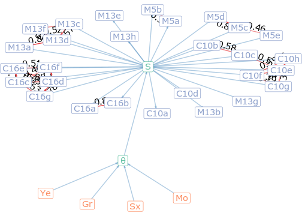

#### Test of local independence

### Local dependence

FP7_buffetvar and FP7_forlystelservar

FP7_forlystelservar and MP13_ikkeOverlapServeringTur

FP7_fyrvaerkerivar and MP13_talevarighed

FP7_indgangvar and FP7_indgangfoerst

FP7_klovnefoerst and MP13_ikkeOverlapServeringTur

FP7_indgangfoerst and FP7_fyrvaerkerisidst, MP13_turvarighed

FP12_dans and FP12_modeltegning, FP12_kostumer

FP12_modeltegning and FP12_kostumer

FP12_kostumer and MP13_busUdFoerst, MP13_busHjemSidst

MP5_overlapSkuespillerOmviser and MP5_udstillingsarkitektFoerst

MP5_skuespillerSidst and MP5_omviserSidst

MP13_busUdFoerst and MP13_busHjemSidst, MP13_talevarighed

MP13_overlapServeringTale and MP13_ikkeOverlapServeringTur

MP13_ikkeOverlapServeringTur and MP13_busHjemSidst, MP13_serveringvarighed, MP13_busUdHjemEns

MP13_busHjemSidst and MP13_talevarighed

|  | F7a | F7b | F7c | F7d | F7e | F7f | F7g | F7h | F12a | F12b | F12c | M5a | M5b | M5c | M5d | M5e | M13a | M13b | M13c | M13d | M13e | M13f | M13g | M13h |
| --- | --- | --- | --- | --- | --- | --- | --- | --- | --- | --- | --- | --- | --- | --- | --- | --- | --- | --- | --- | --- | --- | --- | --- | --- |
| F7a: FP7_buffetvar |  | 0.52 *** | 0.19 | 0.29 | 0.16 | 0.11 | 0.36 | -0.08 | -0.01 | 0.03 | 0.05 | 0.13 | -0.02 | -0.17 | -0.1 | 0.3 | -0.07 | 0.11 | -0.31 | -0.17 | 0.11 | -0.07 | -0.13 | -0.09 |
| F7b: FP7_forlystelservar |  |  | 0.17 | 0.2 | 0.16 | 0.21 | 0.53 | -0.24 | -0.05 | 0.08 | 0.15 | 0.32 | -0.2 | -0.22 | -0.11 | 0.23 | -0.07 | 0.34 | -0.5 ** | -0.23 | 0.03 | -0.05 | -0.21 | -0.13 |
| F7c: FP7_fyrvaerkerivar |  |  |  | 0.29 | 0.37 | 0.03 | 0.34 | 0.12 | -0.13 | -0.1 | -0.07 | -0.12 | 0.21 | 0 | -0.04 | -0.1 | -0.13 | 0.05 | -0.06 | -0.09 | 0.04 | 0.13 | -0.43 * | -0.12 |
| F7d: FP7_indgangvar |  |  |  |  | 0.35 | -0.27 | 1 *** | -0.05 | 0.03 | -0.19 | -0.18 | -0.07 | 0.07 | -0.07 | -0.1 | -0.03 | 0.01 | -0.34 | 0.02 | -0.19 | 0.08 | 0.26 | -0.21 | -0.14 |
| F7e: FP7_optogvar |  |  |  |  |  | 0.02 | 0.36 | 0.15 | 0.02 | -0.21 | -0.01 | -0.03 | 0.12 | -0.11 | -0.14 | 0.09 | 0.05 | 0.01 | -0.09 | 0.04 | -0.05 | 0.02 | -0.21 | -0.16 |
| F7f: FP7_klovnefoerst |  |  |  |  |  |  | 0.11 | 0.2 | -0.22 | -0.1 | -0.13 | 0.21 | -0.11 | -0.18 | -0.28 | 0.08 | 0.08 | 0.24 | -0.42 * | -0.09 | 0 | -0.08 | 0.13 | -0.06 |
| F7g: FP7_indgangfoerst |  |  |  |  |  |  |  | 0.66 *** | -0.4 | -0.19 | -0.07 | 0.43 | -0.06 | -0.51 | -0.38 | 0.11 | 0.36 | 0.36 | 0.28 | 0.51 | 1 *** | 0.46 | 0.25 | -0.04 |
| F7h: FP7_fyrvaerkerisidst |  |  |  |  |  |  |  |  | -0.2 | -0.03 | -0.13 | -0.04 | 0 | -0.02 | 0.03 | -0.08 | -0.03 | 0.09 | 0.17 | 0.13 | 0.03 | 0.08 | -0.07 | 0.19 |
| F12a: FP12_dans |  |  |  |  |  |  |  |  |  | 0.29 ** | 0.54 *** | 0.07 | 0.1 | -0.07 | -0.16 | 0 | -0.09 | 0.02 | -0.05 | -0.18 | -0.14 | -0.19 | -0.08 | -0.24 |
| F12b: FP12_modeltegning |  |  |  |  |  |  |  |  |  |  | 0.46 *** | 0.09 | 0.06 | 0.09 | -0.08 | 0.06 | -0.2 | 0.12 | -0.14 | -0.19 | -0.14 | -0.07 | -0.14 | -0.08 |
| F12c: FP12_kostumer |  |  |  |  |  |  |  |  |  |  |  | 0.11 | 0 | -0.09 | -0.23 | 0.1 | -0.41 *** | 0.19 | -0.19 | -0.38 * | -0.03 | -0.12 | -0.15 | -0.1 |
| M5a: MP5_overlapSkuespillerOmviser |  |  |  |  |  |  |  |  |  |  |  |  | -0.44 *** | -0.06 | 0.04 | 0.06 | -0.04 | 0.34 | -0.31 | -0.15 | 0.04 | -0.22 | 0.12 | 0 |
| M5b: MP5_udstillingsarkitektFoerst |  |  |  |  |  |  |  |  |  |  |  |  |  | 0.19 | 0.22 | -0.32 | -0.04 | -0.12 | -0.09 | -0.16 | -0.1 | -0.05 | -0.23 | -0.12 |
| M5c: MP5_skuespillerSidst |  |  |  |  |  |  |  |  |  |  |  |  |  |  | 0.87 *** | 0.25 | -0.22 | -0.29 | 0.14 | -0.17 | -0.1 | 0.07 | -0.09 | 0.07 |
| M5d: MP5_omviserSidst |  |  |  |  |  |  |  |  |  |  |  |  |  |  |  | 0.17 | 0 | -0.25 | 0.21 | 0.08 | -0.27 | 0.13 | -0.04 | 0.25 |
| M5e: MP5_udstillingLaengst |  |  |  |  |  |  |  |  |  |  |  |  |  |  |  |  | -0.24 | -0.02 | -0.17 | -0.27 | -0.13 | -0.08 | 0.06 | 0.17 |
| M13a: MP13_busUdFoerst |  |  |  |  |  |  |  |  |  |  |  |  |  |  |  |  |  | 0.1 | 0.34 | 0.86 *** | 0.14 | 0.12 | 0.53 *** | 0.19 |
| M13b: MP13_overlapServeringTale |  |  |  |  |  |  |  |  |  |  |  |  |  |  |  |  |  |  | -0.45 * | -0.27 | 0.21 | -0.25 | -0.08 | -0.13 |
| M13c: MP13_ikkeOverlapServeringTur |  |  |  |  |  |  |  |  |  |  |  |  |  |  |  |  |  |  |  | 0.63 *** | 0.28 | 0.66 *** | 0.32 | 0.59 *** |
| M13d: MP13_busHjemSidst |  |  |  |  |  |  |  |  |  |  |  |  |  |  |  |  |  |  |  |  | 0.09 | 0.36 | 0.5 *** | 0.23 |
| M13e: MP13_turvarighed |  |  |  |  |  |  |  |  |  |  |  |  |  |  |  |  |  |  |  |  |  | 0.22 | 0.16 | 0.27 |
| M13f: MP13_serveringvarighed |  |  |  |  |  |  |  |  |  |  |  |  |  |  |  |  |  |  |  |  |  |  | -0.13 | -0.07 |
| M13g: MP13_talevarighed |  |  |  |  |  |  |  |  |  |  |  |  |  |  |  |  |  |  |  |  |  |  |  | 0.27 |
| M13h: MP13_busUdHjemEns |  |  |  |  |  |  |  |  |  |  |  |  |  |  |  |  |  |  |  |  |  |  |  |  |

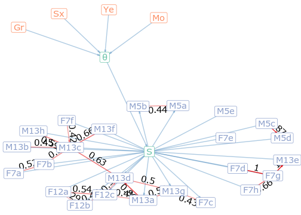

#### Test of local independence

### Local dependence

CP10_delopgB2 and CP10_delopgB3, CP10_delopgB4, FP7_fyrvaerkerivar

CP10_delopgB3 and CP10_delopgB5, CP10_delopgB6, CP10_delopgB8

CP10_delopgB5 and CP10_delopgB6

CP16_baalSidst and CP16_boernAktFoerst, CP16_taleAlene, CP16_faellessangAlene, CP16_buffetVarighed

CP16_taleAlene and CP16_faellessangAlene, CP16_taleVarighed, CP16_faellessangVarighed, CP16_buffetVarighed, FP7_forlystelservar

CP16_faellessangAlene and CP16_taleVarighed, CP16_faellessangVarighed, CP16_buffetVarighed

CP16_taleVarighed and CP16_faellessangVarighed, CP16_buffetVarighed, FP7_fyrvaerkerivar

CP16_faellessangVarighed and CP16_buffetVarighed

FP7_fyrvaerkerivar and FP7_indgangvar, FP7_optogvar

FP12_dans and FP12_modeltegning, FP12_kostumer

FP12_modeltegning and FP12_kostumer

|  | C10a | C10b | C10c | C10d | C10e | C10f | C10g | C10h | C16a | C16b | C16c | C16d | C16e | C16f | C16g | F7a | F7b | F7c | F7d | F7e | F7f | F7g | F7h | F12a | F12b | F12c |
| --- | --- | --- | --- | --- | --- | --- | --- | --- | --- | --- | --- | --- | --- | --- | --- | --- | --- | --- | --- | --- | --- | --- | --- | --- | --- | --- |
| C10a: CP10_delopgB1 |  | 0.06 | 0.37 | -0.02 | 0.2 | 0.14 | 0.03 | 0.21 | 0.36 | 0.12 | 0.11 | -0.09 | 0.05 | 0.07 | 0.04 | 0.19 | 0 | 0.14 | -0.02 | 0.17 | -0.15 | 0.15 | 0.11 | -0.17 | -0.13 | -0.25 |
| C10b: CP10_delopgB2 |  |  | 0.54 *** | 0.35 * | 0.28 | 0.28 | -0.06 | 0.32 | -0.05 | -0.06 | 0 | -0.13 | -0.15 | -0.02 | -0.09 | 0.19 | 0.18 | 0.35 ** | -0.04 | 0.21 | -0.15 | 0.14 | 0.09 | -0.06 | -0.1 | -0.13 |
| C10c: CP10_delopgB3 |  |  |  | 0.44 | 0.74 *** | 0.7 *** | 0.24 | 0.75 *** | 0.12 | 0.33 | -0.21 | -0.15 | 0.01 | -0.07 | -0.22 | 0.17 | 0.14 | 0.14 | 0.38 | 0.3 | 0.09 | 0.47 | -0.06 | 0 | 0.07 | 0.03 |
| C10d: CP10_delopgB4 |  |  |  |  | -0.1 | 0.04 | 0.14 | -0.09 | -0.45 | -0.29 | 0.23 | 0 | -0.14 | -0.12 | -0.22 | -0.2 | -0.27 | 0.12 | 0.23 | -0.03 | -0.15 | 0.24 | -0.05 | -0.24 | -0.21 | -0.04 |
| C10e: CP10_delopgB5 |  |  |  |  |  | 0.85 *** | 0.17 | 0.46 . | 0.19 | 0.14 | 0.03 | 0.06 | 0.01 | -0.07 | -0.11 | -0.06 | 0.15 | 0.01 | -0.12 | -0.01 | -0.02 | 0.58 | 0.03 | -0.13 | -0.12 | -0.15 |
| C10f: CP10_delopgB6 |  |  |  |  |  |  | 0.07 | 0.35 | 0.1 | 0.1 | -0.11 | 0.04 | -0.23 | -0.06 | -0.02 | -0.19 | 0.13 | -0.06 | -0.03 | -0.08 | -0.13 | 0.2 | 0.02 | -0.21 | -0.16 | -0.07 |
| C10g: CP10_delopgB7 |  |  |  |  |  |  |  | 0.09 | -0.04 | 0.03 | 0.07 | -0.03 | 0.14 | -0.21 | 0.17 | -0.02 | 0.05 | -0.12 | -0.14 | -0.08 | 0.01 | 0.11 | 0.07 | -0.06 | -0.22 | -0.11 |
| C10h: CP10_delopgB8 |  |  |  |  |  |  |  |  | 0.41 | 0.4 | 0.15 | 0.4 | 0.28 | 0.28 | 0.07 | 0.12 | 0.22 | 0.12 | 0.16 | 0.26 | -0.04 | 0.23 | 0.08 | -0.12 | 0.01 | -0.17 |
| C16a: CP16_baalSidst |  |  |  |  |  |  |  |  |  | 0.82 *** | 0.59 *** | 0.8 *** | 0.23 | 0.27 | 0.61 ** | 0.07 | -0.19 | -0.02 | 0.34 | 0.07 | 0.14 | 0.04 | -0.04 | -0.33 | -0.15 | -0.28 |
| C16b: CP16_boernAktFoerst |  |  |  |  |  |  |  |  |  |  | 0.24 | 0.26 | -0.02 | -0.05 | 0.3 | 0.02 | 0.19 | -0.25 | -0.06 | -0.06 | 0.23 | -0.08 | 0.19 | -0.18 | -0.07 | -0.15 |
| C16c: CP16_taleAlene |  |  |  |  |  |  |  |  |  |  |  | 0.74 *** | 0.66 *** | 0.42 *** | 0.64 *** | -0.01 | -0.42 *** | -0.08 | 0.01 | -0.15 | 0.05 | -0.02 | -0.16 | -0.22 | -0.23 | -0.27 . |
| C16d: CP16_faellessangAlene |  |  |  |  |  |  |  |  |  |  |  |  | 0.69 *** | 0.74 *** | 0.92 *** | -0.26 | -0.31 | -0.37 | 0.02 | -0.15 | 0.03 | -0.35 | -0.11 | -0.13 | -0.29 | -0.19 |
| C16e: CP16_taleVarighed |  |  |  |  |  |  |  |  |  |  |  |  |  | 0.73 *** | 0.71 *** | -0.12 | -0.29 | -0.48 * | -0.22 | -0.16 | 0.35 | -0.2 | 0.02 | -0.13 | -0.27 | -0.16 |
| C16f: CP16_faellessangVarighed |  |  |  |  |  |  |  |  |  |  |  |  |  |  | 0.56 * | -0.29 | -0.36 | -0.23 | -0.11 | -0.19 | 0.18 | -0.24 | -0.07 | -0.16 | -0.18 | -0.26 |
| C16g: CP16_buffetVarighed |  |  |  |  |  |  |  |  |  |  |  |  |  |  |  | 0.09 | -0.4 | -0.18 | -0.08 | -0.08 | 0.24 | 0.5 | -0.07 | -0.24 | -0.12 | -0.41 |
| F7a: FP7_buffetvar |  |  |  |  |  |  |  |  |  |  |  |  |  |  |  |  | 0.12 | 0.21 | 0.05 | 0.23 | -0.13 | 0.43 | -0.13 | 0.12 | 0.06 | -0.06 |
| F7b: FP7_forlystelservar |  |  |  |  |  |  |  |  |  |  |  |  |  |  |  |  |  | 0.31 | 0.14 | 0.2 | -0.01 | 0.55 | -0.07 | 0 | 0.1 | 0.07 |
| F7c: FP7_fyrvaerkerivar |  |  |  |  |  |  |  |  |  |  |  |  |  |  |  |  |  |  | 0.62 *** | 0.5 *** | -0.12 | 0.6 | 0.04 | -0.1 | -0.03 | -0.14 |
| F7d: FP7_indgangvar |  |  |  |  |  |  |  |  |  |  |  |  |  |  |  |  |  |  |  | 0.29 | -0.17 | -0.03 | -0.06 | -0.15 | 0.02 | -0.04 |
| F7e: FP7_optogvar |  |  |  |  |  |  |  |  |  |  |  |  |  |  |  |  |  |  |  |  | 0.08 | 0.47 | -0.07 | -0.06 | -0.11 | -0.02 |
| F7f: FP7_klovnefoerst |  |  |  |  |  |  |  |  |  |  |  |  |  |  |  |  |  |  |  |  |  | 0.3 | 0.24 | -0.06 | 0 | 0.1 |
| F7g: FP7_indgangfoerst |  |  |  |  |  |  |  |  |  |  |  |  |  |  |  |  |  |  |  |  |  |  | 0.44 | -0.46 | -0.11 | -0.2 |
| F7h: FP7_fyrvaerkerisidst |  |  |  |  |  |  |  |  |  |  |  |  |  |  |  |  |  |  |  |  |  |  |  | -0.01 | -0.03 | -0.07 |
| F12a: FP12_dans |  |  |  |  |  |  |  |  |  |  |  |  |  |  |  |  |  |  |  |  |  |  |  |  | 0.5 *** | 0.6 *** |
| F12b: FP12_modeltegning |  |  |  |  |  |  |  |  |  |  |  |  |  |  |  |  |  |  |  |  |  |  |  |  |  | 0.49 *** |
| F12c: FP12_kostumer |  |  |  |  |  |  |  |  |  |  |  |  |  |  |  |  |  |  |  |  |  |  |  |  |  |  |

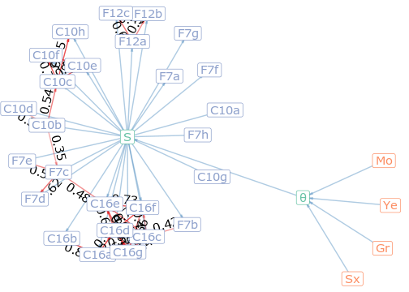

#### Test of Differential Item Functioning

|  | grade | month | sex | year |
| --- | --- | --- | --- | --- |
| MP13_busHjemSidst | -0.17 | 0.13 | -0.37 | 0.18 |
| MP13_busUdFoerst | -0.24 | 0.22 | 0.21 | 0.23 |
| MP13_busUdHjemEns | -0.22 | -0.2 | 0.18 | 0.17 |
| MP13_ikkeOverlapServeringTur | 0.05 | -0.04 | -0.29 | -0.21 |
| MP13_overlapServeringTale | -0.02 | -0.02 | 0.01 | 0.06 |
| MP13_serveringvarighed | 0.2 | -0.03 | 0.26 | -0.14 |
| MP13_talevarighed | -0.06 | 0.12 | 0.26 | -0.02 |
| MP13_turvarighed | 0.01 | 0.1 | 0.24 | 0.02 |
| MP5_omviserSidst | 0.03 | 0.09 | 0.35 | -0.1 |
| MP5_overlapSkuespillerOmviser | 0.12 | -0.3 | 0.16 | -0.08 |
| MP5_skuespillerSidst | -0.23 | 0.13 | -0.05 | 0.07 |
| MP5_udstillingLaengst | 0.16 | -0.05 | 0.11 | -0.14 |
| MP5_udstillingsarkitektFoerst | -0.2 | 0.3 | -0.27 | 0.01 |
| TP1_auditmax | -0.17 | -0.12 | -0.25 | 0.11 |
| TP1_forestillinglaengst | -0.52 | -0.03 | 0.44 | 0.46 |
| TP1_forestillingsidst | -0.23 | 0.44 | 0.13 | 0.17 |
| TP1_kostmax | 0.13 | -0.01 | -0.35 | -0.16 |
| TP1_kostumeefteraudition | -0.3 | 0.13 | -0.18 | 0.24 |
| TP1_lydefterkoebelyd | -0.13 | 0.26 | -0.06 | 0.09 |
| TP1_lydmax | -0.08 | -0.02 | 0.12 | 0.09 |
| TP1_manusfoerst | 0.03 | -0.05 | -0.18 | -0.01 |
| TP1_oeveefteraudition | -0.28 | -0.06 | -0.13 | 0.27 |
| TP4_auditionfoerst | 0.28 | -0.1 | 0.04 | -0.16 |
| TP4_slutfoerst | 0.3 | -0.1 | -0.14 | -0.22 |
| TP4_sminkoerfoerst | 0.15 | -0.15 | 0 | -0.08 |

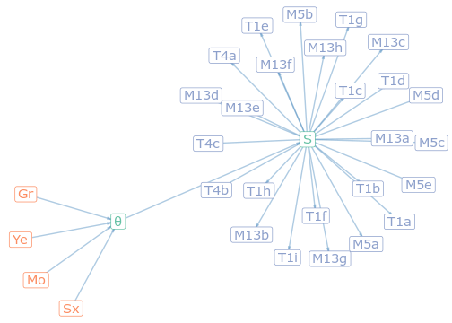

#### Test of Differential Item Functioning

|  | grade | month | sex | year |
| --- | --- | --- | --- | --- |
| CP10_delopgB1 | -0.16 | 0.01 | -0.06 | 0.12 |
| CP10_delopgB2 | 0.1 | -0.01 | 0.02 | -0.02 |
| CP10_delopgB3 | 0.26 | 0.16 | 0.09 | -0.19 |
| CP10_delopgB4 | -0.39 | 0.05 | -0.1 | 0.19 |
| CP10_delopgB5 | 0.4 | 0.08 | -0.2 | -0.4 |
| CP10_delopgB6 | 0.18 | 0.05 | 0.02 | -0.21 |
| CP10_delopgB7 | -0.19 | 0.09 | 0.42 | 0.13 |
| CP10_delopgB8 | 0.37 | 0.35 | 0.15 | -0.1 |
| CP16_boernAktFoerst | 0.04 | 0.02 | 0.04 | 0 |
| CP16_buffetVarighed | 0.11 | -0.08 | -0.37 | -0.24 |
| CP16_baalSidst | 0.21 | -0.08 | -0.42 | -0.2 |
| CP16_faellessangAlene | -0.02 | -0.18 | -0.34 | 0 |
| CP16_faellessangVarighed | -0.11 | 0.01 | -0.04 | 0.19 |
| CP16_taleAlene | -0.15 | -0.01 | -0.04 | 0.16 |
| CP16_taleVarighed | 0.31 | 0.03 | -0.21 | -0.14 |
| TP1_auditmax | -0.04 | 0.13 | 0.24 | 0.17 |
| TP1_forestillinglaengst | 0.31 | 0.16 | 0 | -0.42 |
| TP1_forestillingsidst | -0.32 | 0.07 | 0 | 0.16 |
| TP1_kostmax | -0.23 | -0.02 | 0.03 | 0.12 |
| TP1_kostumeefteraudition | 0.04 | 0 | 0.2 | 0.03 |
| TP1_lydefterkoebelyd | -0.22 | -0.05 | 0.12 | 0.25 |
| TP1_lydmax | -0.27 | 0.07 | 0.22 | 0.28 |
| TP1_manusfoerst | -0.19 | 0 | 0.19 | 0.09 |
| TP1_oeveefteraudition | 0.08 | -0.04 | -0.14 | 0.03 |
| TP4_auditionfoerst | 0.19 | -0.08 | -0.11 | -0.13 |
| TP4_slutfoerst | 0.3 | -0.02 | -0.03 | -0.27 |
| TP4_sminkoerfoerst | -0.01 | -0.17 | -0.03 | -0.02 |

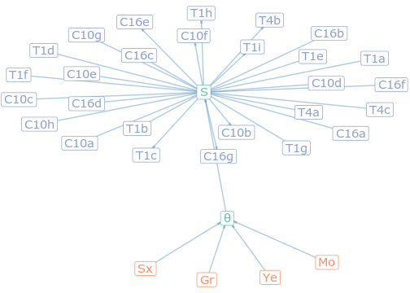

#### Test of Differential Item Functioning

### Differential Item Functioning

TP4_sminkoerfoerst and grade

|  | grade | month | sex | year |
| --- | --- | --- | --- | --- |
| FP12_dans | 0.12 | -0.1 | 0.06 | -0.05 |
| FP12_kostumer | -0.11 | 0.07 | -0.22 | 0.08 |
| FP12_modeltegning | 0.06 | 0.01 | 0.22 | -0.08 |
| FP7_buffetvar | -0.15 | 0.17 | 0.32 | 0 |
| FP7_forlystelservar | -0.12 | -0.03 | 0.18 | 0.18 |
| FP7_fyrvaerkerisidst | 0.3 | -0.08 | 0.19 | -0.22 |
| FP7_fyrvaerkerivar | -0.34 | -0.02 | -0.15 | 0.21 |
| FP7_indgangfoerst | 0.68 | 0.04 | 0.7 | -0.25 |
| FP7_indgangvar | -0.47 | -0.01 | 0.02 | 0.25 |
| FP7_klovnefoerst | 0.26 | 0.12 | -0.3 | -0.12 |
| FP7_optogvar | -0.12 | -0.09 | 0.2 | 0.11 |
| TP1_auditmax | 0.03 | 0.04 | -0.08 | 0.03 |
| TP1_forestillinglaengst | -0.2 | 0.08 | 0.12 | -0.13 |
| TP1_forestillingsidst | 0.1 | 0 | -0.24 | -0.1 |
| TP1_kostmax | 0.12 | -0.13 | -0.23 | -0.14 |
| TP1_kostumeefteraudition | -0.22 | -0.13 | 0.01 | 0.24 |
| TP1_lydefterkoebelyd | 0.01 | -0.04 | -0.11 | -0.09 |
| TP1_lydmax | 0.32 | -0.01 | 0.12 | -0.17 |
| TP1_manusfoerst | -0.03 | 0 | -0.37 | -0.02 |
| TP1_oeveefteraudition | -0.06 | -0.03 | 0.2 | 0.14 |
| TP4_auditionfoerst | 0.42 | 0.01 | 0.1 | -0.38 |
| TP4_slutfoerst | 0.25 | 0.14 | 0.09 | -0.23 |
| TP4_sminkoerfoerst | -0.56 *** | 0.02 | 0.15 | 0.38 |

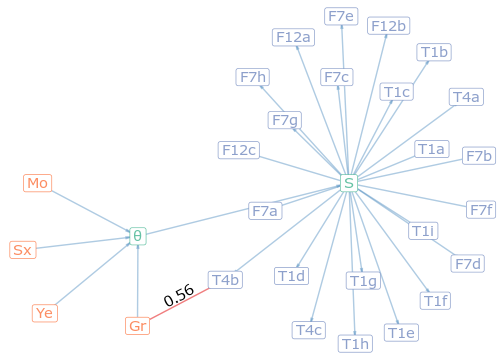

#### Test of Differential Item Functioning

|  | grade | month | sex | year |
| --- | --- | --- | --- | --- |
| CP10_delopgB1 | 0.02 | 0.17 | 0.28 | -0.07 |
| CP10_delopgB2 | -0.01 | -0.02 | -0.03 | 0.08 |
| CP10_delopgB3 | 0.11 | -0.18 | 0.23 | 0.1 |
| CP10_delopgB4 | -0.19 | 0.06 | 0.14 | 0.1 |
| CP10_delopgB5 | -0.09 | 0.01 | -0.04 | 0.09 |
| CP10_delopgB6 | 0.12 | 0.04 | -0.17 | -0.09 |
| CP10_delopgB7 | -0.22 | 0.03 | 0.25 | 0.17 |
| CP10_delopgB8 | 0.41 | -0.09 | 0.39 | -0.15 |
| CP16_boernAktFoerst | 0.24 | 0.07 | 0.08 | -0.24 |
| CP16_buffetVarighed | -0.09 | 0.14 | -0.24 | 0.11 |
| CP16_baalSidst | 0.19 | 0.21 | 0.18 | -0.07 |
| CP16_faellessangAlene | 0.03 | -0.04 | 0.02 | -0.01 |
| CP16_faellessangVarighed | -0.08 | -0.22 | -0.24 | 0.08 |
| CP16_taleAlene | 0.14 | 0 | -0.36 | -0.12 |
| CP16_taleVarighed | 0.33 | -0.29 | -0.18 | -0.15 |
| MP13_busHjemSidst | 0.29 | -0.03 | -0.08 | -0.24 |
| MP13_busUdFoerst | 0.13 | 0.03 | 0.02 | -0.12 |
| MP13_busUdHjemEns | -0.29 | 0.17 | 0.07 | 0.11 |
| MP13_ikkeOverlapServeringTur | -0.01 | 0.02 | -0.29 | -0.09 |
| MP13_overlapServeringTale | -0.17 | -0.08 | 0.16 | 0.11 |
| MP13_serveringvarighed | 0.21 | -0.08 | -0.21 | -0.25 |
| MP13_talevarighed | 0.25 | 0.01 | 0.25 | -0.17 |
| MP13_turvarighed | -0.02 | 0.07 | 0.16 | 0.11 |
| MP5_omviserSidst | -0.28 | 0.03 | -0.13 | 0.26 |
| MP5_overlapSkuespillerOmviser | -0.07 | 0.02 | 0.11 | 0.09 |
| MP5_skuespillerSidst | -0.12 | -0.07 | -0.08 | 0.11 |
| MP5_udstillingLaengst | 0.03 | 0.09 | 0.35 | 0.01 |
| MP5_udstillingsarkitektFoerst | 0 | 0.01 | -0.05 | -0.01 |

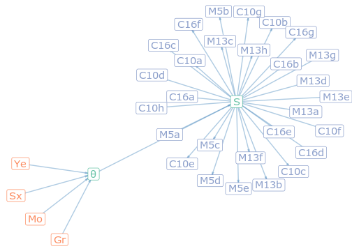

#### Test of Differential Item Functioning

|  | grade | month | sex | year |
| --- | --- | --- | --- | --- |
| FP12_dans | -0.13 | 0.05 | 0.04 | 0.09 |
| FP12_kostumer | -0.23 | 0.07 | 0.14 | 0.22 |
| FP12_modeltegning | 0 | 0.01 | -0.16 | -0.01 |
| FP7_buffetvar | 0.27 | -0.11 | 0.25 | -0.22 |
| FP7_forlystelservar | -0.24 | -0.06 | 0.03 | 0.2 |
| FP7_fyrvaerkerisidst | 0.05 | -0.05 | -0.02 | -0.04 |
| FP7_fyrvaerkerivar | -0.12 | 0.01 | -0.16 | 0.09 |
| FP7_indgangfoerst | 0.16 | 0.02 | -0.07 | 0.01 |
| FP7_indgangvar | -0.32 | 0.12 | 0.02 | 0.25 |
| FP7_klovnefoerst | 0.01 | 0.05 | 0.01 | -0.05 |
| FP7_optogvar | 0.17 | 0.03 | -0.22 | -0.05 |
| MP13_busHjemSidst | 0.25 | 0.1 | -0.2 | -0.23 |
| MP13_busUdFoerst | 0 | 0.12 | 0.04 | -0.14 |
| MP13_busUdHjemEns | -0.37 | -0.09 | -0.06 | 0.28 |
| MP13_ikkeOverlapServeringTur | 0.17 | -0.02 | 0.12 | -0.17 |
| MP13_overlapServeringTale | -0.12 | 0.02 | 0.05 | 0.06 |
| MP13_serveringvarighed | -0.02 | 0 | -0.18 | 0 |
| MP13_talevarighed | 0.06 | -0.16 | 0.4 | 0.02 |
| MP13_turvarighed | -0.05 | -0.03 | 0.18 | 0.06 |
| MP5_omviserSidst | -0.02 | -0.12 | 0.3 | 0 |
| MP5_overlapSkuespillerOmviser | -0.05 | 0.05 | -0.1 | 0.04 |
| MP5_skuespillerSidst | -0.16 | -0.1 | 0.29 | 0.13 |
| MP5_udstillingLaengst | 0.06 | -0.04 | -0.11 | -0.02 |
| MP5_udstillingsarkitektFoerst | 0.18 | 0 | -0.18 | -0.09 |

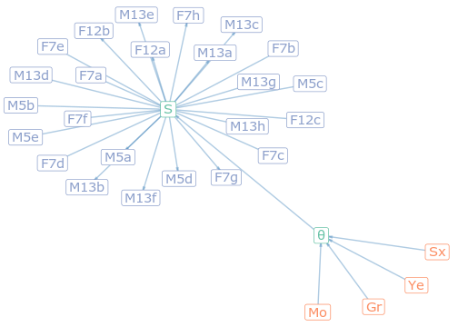

#### Test of Differential Item Functioning

### Differential Item Functioning

FP7_indgangvar and sex

FP7_indgangfoerst and sex

|  | grade | month | sex | year |
| --- | --- | --- | --- | --- |
| CP10_delopgB1 | 0.06 | -0.06 | 0.18 | -0.05 |
| CP10_delopgB2 | -0.02 | 0.03 | 0.02 | 0.09 |
| CP10_delopgB3 | 0.16 | 0.18 | 0.33 | 0.21 |
| CP10_delopgB4 | 0.12 | 0.04 | -0.13 | -0.1 |
| CP10_delopgB5 | 0.16 | -0.1 | -0.02 | -0.06 |
| CP10_delopgB6 | 0.21 | -0.22 | 0 | -0.03 |
| CP10_delopgB7 | 0.09 | -0.06 | 0.15 | -0.01 |
| CP10_delopgB8 | 0.36 | 0.41 | 0.33 | -0.12 |
| CP16_boernAktFoerst | 0.15 | 0.04 | 0.19 | -0.17 |
| CP16_buffetVarighed | -0.15 | -0.06 | 0.18 | 0.12 |
| CP16_baalSidst | -0.21 | -0.11 | 0.3 | 0.27 |
| CP16_faellessangAlene | -0.08 | -0.28 | -0.2 | 0.17 |
| CP16_faellessangVarighed | 0 | -0.05 | -0.3 | -0.06 |
| CP16_taleAlene | -0.06 | -0.09 | -0.2 | 0 |
| CP16_taleVarighed | 0.2 | 0 | -0.18 | -0.25 |
| FP12_dans | 0.15 | 0.08 | -0.05 | -0.02 |
| FP12_kostumer | -0.09 | 0.19 | -0.17 | 0.1 |
| FP12_modeltegning | -0.04 | 0.06 | -0.31 | -0.02 |
| FP7_buffetvar | 0.05 | 0.13 | 0.17 | -0.05 |
| FP7_forlystelservar | -0.22 | 0.13 | 0.1 | 0.27 |
| FP7_fyrvaerkerisidst | 0.22 | -0.07 | -0.04 | -0.26 |
| FP7_fyrvaerkerivar | -0.19 | -0.05 | 0.14 | 0.22 |
| FP7_indgangfoerst | -0.36 | -0.22 | -1 *** | 0.19 |
| FP7_indgangvar | -0.51 | 0.11 | 0.57 * | 0.29 |
| FP7_klovnefoerst | -0.11 | -0.01 | 0.33 | -0.02 |
| FP7_optogvar | -0.18 | -0.2 | -0.09 | 0.21 |

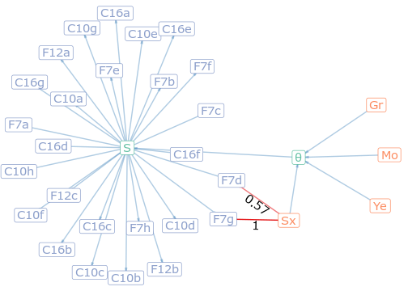